# Part-1

## About the dataset

This is perhaps the best known database to be found in the pattern recognition literature. The data set contains 3 classes of 50 instances each, where each class refers to a type of iris plant. One class is linearly separable from the other 2; the latter are NOT linearly separable from each other.

Attribute Information:

1. sepal length in cm
2. sepal width in cm
3. petal length in cm
4. petal width in cm
5. class: -- Iris Setosa -- Iris Versicolour -- Iris Virginica

### Read the dataset and store it in the dataframe named Iris

```python
import pandas as pd
Iris=pd.read_csv("Iris_external.csv")
```

### Find out the datatypes of each and every column

```python
Iris.dtypes
```

```
Sepal Length (in cm)    float64
Sepal Width in (cm)     float64
Petal length (in cm)    float64
Petal width (in cm)     float64
Class                    object
dtype: object
```

### Print top 10 & bottom 10 samples from the dataframe

```python
Iris.head(10)
```

|  | Sepal Length (in cm) | Sepal Width in (cm) | Petal length (in cm) | Petal width (in cm) | Class |
| --- | --- | --- | --- | --- | --- |
| 0 | 5.1 | 3.5 | 1.4 | 0.2 | Iris-setosa |
| 1 | 4.9 | 3.0 | 1.4 | 0.2 | Iris-setosa |
| 2 | 4.7 | 3.2 | 1.3 | 0.2 | Iris-setosa |
| 3 | 4.6 | 3.1 | 1.5 | 0.2 | Iris-setosa |
| 4 | 5.0 | 3.6 | 1.4 | 0.2 | Iris-setosa |
| 5 | 5.4 | 3.9 | 1.7 | 0.4 | Iris-setosa |
| 6 | 4.6 | 3.4 | 1.4 | 0.3 | Iris-setosa |
| 7 | 5.0 | 3.4 | 1.5 | 0.2 | Iris-setosa |
| 8 | 4.4 | 2.9 | 1.4 | 0.2 | Iris-setosa |
| 9 | 4.9 | 3.1 | 1.5 | 0.1 | Iris-setosa |

```python
Iris.tail(10)
```

|  | Sepal Length (in cm) | Sepal Width in (cm) | Petal length (in cm) | Petal width (in cm) | Class |
| --- | --- | --- | --- | --- | --- |
| 140 | 6.7 | 3.1 | 5.6 | 2.4 | Iris-virginica |
| 141 | 6.9 | 3.1 | 5.1 | 2.3 | Iris-virginica |
| 142 | 5.8 | 2.7 | 5.1 | 1.9 | Iris-virginica |
| 143 | 6.8 | 3.2 | 5.9 | 2.3 | Iris-virginica |
| 144 | 6.7 | 3.3 | 5.7 | 2.5 | Iris-virginica |
| 145 | 6.7 | 3.0 | 5.2 | 2.3 | Iris-virginica |
| 146 | 6.3 | 2.5 | 5.0 | 1.9 | Iris-virginica |
| 147 | 6.5 | 3.0 | 5.2 | 2.0 | Iris-virginica |
| 148 | 6.2 | 3.4 | 5.4 | 2.3 | Iris-virginica |
| 149 | 5.9 | 3.0 | 5.1 | 1.8 | Iris-virginica |

### Find the shape of the dataset

```python
Iris.shape
```

```
(150, 5)
```

```python
Iris.index = Iris['Class']
```

### Use iloc function to print all the rows of the 3rd column

```python
Iris.iloc[:,2:3]
```

| Class | Petal length (in cm) |
| --- | --- |
| Iris-setosa | 1.4 |
| Iris-setosa | 1.4 |
| Iris-setosa | 1.3 |
| Iris-setosa | 1.5 |
| Iris-setosa | 1.4 |
| Iris-setosa | 1.7 |
| Iris-setosa | 1.4 |
| Iris-setosa | 1.5 |
| Iris-setosa | 1.4 |
| Iris-setosa | 1.5 |
| Iris-setosa | 1.5 |
| Iris-setosa | 1.6 |
| Iris-setosa | 1.4 |
| Iris-setosa | 1.1 |
| Iris-setosa | 1.2 |
| Iris-setosa | 1.5 |
| Iris-setosa | 1.3 |
| Iris-setosa | 1.4 |
| Iris-setosa | 1.7 |
| Iris-setosa | 1.5 |
| Iris-setosa | 1.7 |
| Iris-setosa | 1.5 |
| Iris-setosa | 1.0 |
| Iris-setosa | 1.7 |
| Iris-setosa | 1.9 |
| Iris-setosa | 1.6 |
| Iris-setosa | 1.6 |
| Iris-setosa | 1.5 |
| Iris-setosa | 1.4 |
| Iris-setosa | 1.6 |
| ... | ... |
| Iris-virginica | 5.7 |
| Iris-virginica | 4.9 |
| Iris-virginica | 6.7 |
| Iris-virginica | 4.9 |
| Iris-virginica | 5.7 |
| Iris-virginica | 6.0 |
| Iris-virginica | 4.8 |
| Iris-virginica | 4.9 |
| Iris-virginica | 5.6 |
| Iris-virginica | 5.8 |
| Iris-virginica | 6.1 |
| Iris-virginica | 6.4 |
| Iris-virginica | 5.6 |
| Iris-virginica | 5.1 |
| Iris-virginica | 5.6 |
| Iris-virginica | 6.1 |
| Iris-virginica | 5.6 |
| Iris-virginica | 5.5 |
| Iris-virginica | 4.8 |
| Iris-virginica | 5.4 |
| Iris-virginica | 5.6 |
| Iris-virginica | 5.1 |
| Iris-virginica | 5.1 |
| Iris-virginica | 5.9 |
| Iris-virginica | 5.7 |
| Iris-virginica | 5.2 |
| Iris-virginica | 5.0 |
| Iris-virginica | 5.2 |
| Iris-virginica | 5.4 |
| Iris-virginica | 5.1 |

150 rows × 1 columns

### Slicing

Print only the Sepal width and Sepal Length for first 10 rows

```python
Iris.iloc[:10,:2]
```

| Class | Sepal Length (in cm) | Sepal Width in (cm) |
| --- | --- | --- |
| Iris-setosa | 5.1 | 3.5 |
| Iris-setosa | 4.9 | 3.0 |
| Iris-setosa | 4.7 | 3.2 |
| Iris-setosa | 4.6 | 3.1 |
| Iris-setosa | 5.0 | 3.6 |
| Iris-setosa | 5.4 | 3.9 |
| Iris-setosa | 4.6 | 3.4 |
| Iris-setosa | 5.0 | 3.4 |
| Iris-setosa | 4.4 | 2.9 |
| Iris-setosa | 4.9 | 3.1 |

### Using Logical statements for indexing

Print all the columns of row which has class name "Iris-setosa"

```python
Iris[Iris['Class']=="Iris-setosa"]
```

| Class | Sepal Length (in cm) | Sepal Width in (cm) | Petal length (in cm) | Petal width (in cm) | Class |
| --- | --- | --- | --- | --- | --- |
| Iris-setosa | 5.1 | 3.5 | 1.4 | 0.2 | Iris-setosa |
| Iris-setosa | 4.9 | 3.0 | 1.4 | 0.2 | Iris-setosa |
| Iris-setosa | 4.7 | 3.2 | 1.3 | 0.2 | Iris-setosa |
| Iris-setosa | 4.6 | 3.1 | 1.5 | 0.2 | Iris-setosa |
| Iris-setosa | 5.0 | 3.6 | 1.4 | 0.2 | Iris-setosa |
| Iris-setosa | 5.4 | 3.9 | 1.7 | 0.4 | Iris-setosa |
| Iris-setosa | 4.6 | 3.4 | 1.4 | 0.3 | Iris-setosa |
| Iris-setosa | 5.0 | 3.4 | 1.5 | 0.2 | Iris-setosa |
| Iris-setosa | 4.4 | 2.9 | 1.4 | 0.2 | Iris-setosa |
| Iris-setosa | 4.9 | 3.1 | 1.5 | 0.1 | Iris-setosa |
| Iris-setosa | 5.4 | 3.7 | 1.5 | 0.2 | Iris-setosa |
| Iris-setosa | 4.8 | 3.4 | 1.6 | 0.2 | Iris-setosa |
| Iris-setosa | 4.8 | 3.0 | 1.4 | 0.1 | Iris-setosa |
| Iris-setosa | 4.3 | 3.0 | 1.1 | 0.1 | Iris-setosa |
| Iris-setosa | 5.8 | 4.0 | 1.2 | 0.2 | Iris-setosa |
| Iris-setosa | 5.7 | 4.4 | 1.5 | 0.4 | Iris-setosa |
| Iris-setosa | 5.4 | 3.9 | 1.3 | 0.4 | Iris-setosa |
| Iris-setosa | 5.1 | 3.5 | 1.4 | 0.3 | Iris-setosa |
| Iris-setosa | 5.7 | 3.8 | 1.7 | 0.3 | Iris-setosa |
| Iris-setosa | 5.1 | 3.8 | 1.5 | 0.3 | Iris-setosa |
| Iris-setosa | 5.4 | 3.4 | 1.7 | 0.2 | Iris-setosa |
| Iris-setosa | 5.1 | 3.7 | 1.5 | 0.4 | Iris-setosa |
| Iris-setosa | 4.6 | 3.6 | 1.0 | 0.2 | Iris-setosa |
| Iris-setosa | 5.1 | 3.3 | 1.7 | 0.5 | Iris-setosa |
| Iris-setosa | 4.8 | 3.4 | 1.9 | 0.2 | Iris-setosa |
| Iris-setosa | 5.0 | 3.0 | 1.6 | 0.2 | Iris-setosa |
| Iris-setosa | 5.0 | 3.4 | 1.6 | 0.4 | Iris-setosa |
| Iris-setosa | 5.2 | 3.5 | 1.5 | 0.2 | Iris-setosa |
| Iris-setosa | 5.2 | 3.4 | 1.4 | 0.2 | Iris-setosa |
| Iris-setosa | 4.7 | 3.2 | 1.6 | 0.2 | Iris-setosa |
| Iris-setosa | 4.8 | 3.1 | 1.6 | 0.2 | Iris-setosa |
| Iris-setosa | 5.4 | 3.4 | 1.5 | 0.4 | Iris-setosa |
| Iris-setosa | 5.2 | 4.1 | 1.5 | 0.1 | Iris-setosa |
| Iris-setosa | 5.5 | 4.2 | 1.4 | 0.2 | Iris-setosa |
| Iris-setosa | 4.9 | 3.1 | 1.5 | 0.1 | Iris-setosa |
| Iris-setosa | 5.0 | 3.2 | 1.2 | 0.2 | Iris-setosa |
| Iris-setosa | 5.5 | 3.5 | 1.3 | 0.2 | Iris-setosa |
| Iris-setosa | 4.9 | 3.1 | 1.5 | 0.1 | Iris-setosa |
| Iris-setosa | 4.4 | 3.0 | 1.3 | 0.2 | Iris-setosa |
| Iris-setosa | 5.1 | 3.4 | 1.5 | 0.2 | Iris-setosa |
| Iris-setosa | 5.0 | 3.5 | 1.3 | 0.3 | Iris-setosa |
| Iris-setosa | 4.5 | 2.3 | 1.3 | 0.3 | Iris-setosa |
| Iris-setosa | 4.4 | 3.2 | 1.3 | 0.2 | Iris-setosa |
| Iris-setosa | 5.0 | 3.5 | 1.6 | 0.6 | Iris-setosa |
| Iris-setosa | 5.1 | 3.8 | 1.9 | 0.4 | Iris-setosa |
| Iris-setosa | 4.8 | 3.0 | 1.4 | 0.3 | Iris-setosa |
| Iris-setosa | 5.1 | 3.8 | 1.6 | 0.2 | Iris-setosa |
| Iris-setosa | 4.6 | 3.2 | 1.4 | 0.2 | Iris-setosa |
| Iris-setosa | 5.3 | 3.7 | 1.5 | 0.2 | Iris-setosa |
| Iris-setosa | 5.0 | 3.3 | 1.4 | 0.2 | Iris-setosa |

### Multiply Sepal Length and width and store it under the column name "SepalExtra" in the same Iris dataframe

```python
Iris["SepalExtra"]=Iris["Sepal Length (in cm)"]* Iris["Sepal Width in (cm)"]
```

```python
Iris.mean()
```

```
Sepal Length (in cm)     5.843333
Sepal Width in (cm)      3.054000
Petal length (in cm)     3.758667
Petal width (in cm)      1.198667
SepalExtra              17.806533
dtype: float64
```

```python
Iris.var
```

[output not shown]

[output cut: 138 more lines]

[output not shown]

### Write a function that accepts two numbers as input and prints them - Pass the Sepal length and sepal width of 5th row and print the output

```python
def printFunction(a,b):
    print(a)
    print(b)

a=Iris.iloc[4:5,:1]
b=Iris.iloc[4:5,1:2]
printFunction(a , b)
```

```
             Sepal Length (in cm)
Class
Iris-setosa                   5.0
             Sepal Width in (cm)
Class
Iris-setosa                  3.6
```

*Range = Max value - Min value (in the column)*

```python
Iris.head()
```

| Class | Sepal Length (in cm) | Sepal Width in (cm) | Petal length (in cm) | Petal width (in cm) | Class | SepalExtra |
| --- | --- | --- | --- | --- | --- | --- |
| Iris-setosa | 5.1 | 3.5 | 1.4 | 0.2 | Iris-setosa | 17.85 |
| Iris-setosa | 4.9 | 3.0 | 1.4 | 0.2 | Iris-setosa | 14.70 |
| Iris-setosa | 4.7 | 3.2 | 1.3 | 0.2 | Iris-setosa | 15.04 |
| Iris-setosa | 4.6 | 3.1 | 1.5 | 0.2 | Iris-setosa | 14.26 |
| Iris-setosa | 5.0 | 3.6 | 1.4 | 0.2 | Iris-setosa | 18.00 |

```python
def range(max,min):
    range=max-min
    print(range)

max= Iris["Sepal Length (in cm)"].max()
min=Iris["Sepal Length (in cm)"].min()
range( max,min)
```

```
3.6000000000000005
```

```python
max= Iris["Sepal Width in (cm)"].max()
min=Iris["Sepal Width in (cm)"].min()
range( max,min)
```

```
2.4000000000000004
```

```python
max=Iris["Petal width (in cm)"].max()
min=Iris["Petal width (in cm)"].min()
range(max,min)
```

```
2.4
```

```python
max=Iris["SepalExtra"].max()
min=Iris["SepalExtra"].min()
range(max,min)
```

```
20.02
```

```python
Iris.sort_values("Petal width (in cm)")
```

| Class | Sepal Length (in cm) | Sepal Width in (cm) | Petal length (in cm) | Petal width (in cm) | Class | SepalExtra |
| --- | --- | --- | --- | --- | --- | --- |
| Iris-setosa | 5.2 | 4.1 | 1.5 | 0.1 | Iris-setosa | 21.32 |
| Iris-setosa | 4.3 | 3.0 | 1.1 | 0.1 | Iris-setosa | 12.90 |
| Iris-setosa | 4.9 | 3.1 | 1.5 | 0.1 | Iris-setosa | 15.19 |
| Iris-setosa | 4.9 | 3.1 | 1.5 | 0.1 | Iris-setosa | 15.19 |
| Iris-setosa | 4.8 | 3.0 | 1.4 | 0.1 | Iris-setosa | 14.40 |
| Iris-setosa | 4.9 | 3.1 | 1.5 | 0.1 | Iris-setosa | 15.19 |
| Iris-setosa | 5.1 | 3.5 | 1.4 | 0.2 | Iris-setosa | 17.85 |
| Iris-setosa | 5.2 | 3.5 | 1.5 | 0.2 | Iris-setosa | 18.20 |
| Iris-setosa | 5.2 | 3.4 | 1.4 | 0.2 | Iris-setosa | 17.68 |
| Iris-setosa | 4.7 | 3.2 | 1.6 | 0.2 | Iris-setosa | 15.04 |
| Iris-setosa | 4.8 | 3.1 | 1.6 | 0.2 | Iris-setosa | 14.88 |
| Iris-setosa | 5.5 | 4.2 | 1.4 | 0.2 | Iris-setosa | 23.10 |
| Iris-setosa | 5.5 | 3.5 | 1.3 | 0.2 | Iris-setosa | 19.25 |
| Iris-setosa | 4.4 | 3.0 | 1.3 | 0.2 | Iris-setosa | 13.20 |
| Iris-setosa | 5.1 | 3.4 | 1.5 | 0.2 | Iris-setosa | 17.34 |
| Iris-setosa | 4.4 | 3.2 | 1.3 | 0.2 | Iris-setosa | 14.08 |
| Iris-setosa | 5.1 | 3.8 | 1.6 | 0.2 | Iris-setosa | 19.38 |
| Iris-setosa | 4.6 | 3.2 | 1.4 | 0.2 | Iris-setosa | 14.72 |
| Iris-setosa | 5.3 | 3.7 | 1.5 | 0.2 | Iris-setosa | 19.61 |
| Iris-setosa | 5.0 | 3.3 | 1.4 | 0.2 | Iris-setosa | 16.50 |
| Iris-setosa | 5.0 | 3.0 | 1.6 | 0.2 | Iris-setosa | 15.00 |
| Iris-setosa | 4.8 | 3.4 | 1.9 | 0.2 | Iris-setosa | 16.32 |
| Iris-setosa | 5.0 | 3.2 | 1.2 | 0.2 | Iris-setosa | 16.00 |
| Iris-setosa | 4.6 | 3.1 | 1.5 | 0.2 | Iris-setosa | 14.26 |
| Iris-setosa | 4.7 | 3.2 | 1.3 | 0.2 | Iris-setosa | 15.04 |
| Iris-setosa | 5.0 | 3.4 | 1.5 | 0.2 | Iris-setosa | 17.00 |
| Iris-setosa | 4.4 | 2.9 | 1.4 | 0.2 | Iris-setosa | 12.76 |
| Iris-setosa | 5.4 | 3.7 | 1.5 | 0.2 | Iris-setosa | 19.98 |
| Iris-setosa | 5.0 | 3.6 | 1.4 | 0.2 | Iris-setosa | 18.00 |
| Iris-setosa | 4.8 | 3.4 | 1.6 | 0.2 | Iris-setosa | 16.32 |
| ... | ... | ... | ... | ... | ... | ... |
| Iris-virginica | 6.4 | 2.7 | 5.3 | 1.9 | Iris-virginica | 17.28 |
| Iris-virginica | 5.6 | 2.8 | 4.9 | 2.0 | Iris-virginica | 15.68 |
| Iris-virginica | 7.7 | 2.8 | 6.7 | 2.0 | Iris-virginica | 21.56 |
| Iris-virginica | 6.5 | 3.0 | 5.2 | 2.0 | Iris-virginica | 19.50 |
| Iris-virginica | 5.7 | 2.5 | 5.0 | 2.0 | Iris-virginica | 14.25 |
| Iris-virginica | 7.9 | 3.8 | 6.4 | 2.0 | Iris-virginica | 30.02 |
| Iris-virginica | 6.5 | 3.2 | 5.1 | 2.0 | Iris-virginica | 20.80 |
| Iris-virginica | 6.9 | 3.1 | 5.4 | 2.1 | Iris-virginica | 21.39 |
| Iris-virginica | 7.1 | 3.0 | 5.9 | 2.1 | Iris-virginica | 21.30 |
| Iris-virginica | 6.8 | 3.0 | 5.5 | 2.1 | Iris-virginica | 20.40 |
| Iris-virginica | 7.6 | 3.0 | 6.6 | 2.1 | Iris-virginica | 22.80 |
| Iris-virginica | 6.7 | 3.3 | 5.7 | 2.1 | Iris-virginica | 22.11 |
| Iris-virginica | 6.4 | 2.8 | 5.6 | 2.1 | Iris-virginica | 17.92 |
| Iris-virginica | 7.7 | 3.8 | 6.7 | 2.2 | Iris-virginica | 29.26 |
| Iris-virginica | 6.4 | 2.8 | 5.6 | 2.2 | Iris-virginica | 17.92 |
| Iris-virginica | 6.5 | 3.0 | 5.8 | 2.2 | Iris-virginica | 19.50 |
| Iris-virginica | 6.9 | 3.2 | 5.7 | 2.3 | Iris-virginica | 22.08 |
| Iris-virginica | 6.4 | 3.2 | 5.3 | 2.3 | Iris-virginica | 20.48 |
| Iris-virginica | 6.2 | 3.4 | 5.4 | 2.3 | Iris-virginica | 21.08 |
| Iris-virginica | 6.9 | 3.1 | 5.1 | 2.3 | Iris-virginica | 21.39 |
| Iris-virginica | 6.8 | 3.2 | 5.9 | 2.3 | Iris-virginica | 21.76 |
| Iris-virginica | 6.7 | 3.0 | 5.2 | 2.3 | Iris-virginica | 20.10 |
| Iris-virginica | 7.7 | 2.6 | 6.9 | 2.3 | Iris-virginica | 20.02 |
| Iris-virginica | 7.7 | 3.0 | 6.1 | 2.3 | Iris-virginica | 23.10 |
| Iris-virginica | 6.3 | 3.4 | 5.6 | 2.4 | Iris-virginica | 21.42 |
| Iris-virginica | 6.7 | 3.1 | 5.6 | 2.4 | Iris-virginica | 20.77 |
| Iris-virginica | 5.8 | 2.8 | 5.1 | 2.4 | Iris-virginica | 16.24 |
| Iris-virginica | 6.3 | 3.3 | 6.0 | 2.5 | Iris-virginica | 20.79 |
| Iris-virginica | 6.7 | 3.3 | 5.7 | 2.5 | Iris-virginica | 22.11 |
| Iris-virginica | 7.2 | 3.6 | 6.1 | 2.5 | Iris-virginica | 25.92 |

150 rows × 6 columns

# Part-2

## The dataset HR contains information collected from the survey floated by a HR within the company.

As a part of this lab, you are expected to answer the below questions

### Import numpy and Pandas

```python
import numpy as num
import pandas as pd
```

### Import the dataset (Note: The dataset is in .txt format) - Make sure to use delimiters

```python
HR = pd.read_csv('HR_external.txt',delimiter="\t")
```

### Print the no of rows and columns in the dataset

```python
HR.shape
```

```
(1470, 35)
```

### Find out the type of each and every column in the dataset

```python
HR.dtypes
```

```
Individual                  object
Attrition                   object
Age                          int64
BusinessTravel               int64
DailyRate                    int64
Department                   int64
DistanceFromHome             int64
Education                    int64
EducationField               int64
EmployeeCount                int64
EmployeeNumber               int64
EnvironmentSatisfaction      int64
Gender                       int64
HourlyRate                   int64
JobInvolvement               int64
JobLevel                     int64
JobRole                      int64
JobSatisfaction              int64
MaritalStatus                int64
MonthlyIncome                int64
MonthlyRate                  int64
NumCompaniesWorked           int64
OverTime                     int64
PercentSalaryHike            int64
PerformanceRating            int64
RelationshipSatisfaction     int64
StandardHours                int64
StockOptionLevel             int64
TotalWorkingYears            int64
TrainingTimesLastYear        int64
WorkLifeBalance              int64
YearsAtCompany               int64
YearsInCurrentRole           int64
YearsSinceLastPromotion      int64
YearsWithCurrManager         int64
dtype: object
```

```python
HR.iloc[:,2:11]
```

|  | Age | BusinessTravel | DailyRate | Department | DistanceFromHome | Education | EducationField | EmployeeCount | EmployeeNumber |
| --- | --- | --- | --- | --- | --- | --- | --- | --- | --- |
| 0 | 41 | 1 | 1102 | 1 | 1 | 2 | 1 | 1 | 1 |
| 1 | 49 | 2 | 279 | 2 | 8 | 1 | 1 | 1 | 2 |
| 2 | 37 | 1 | 1373 | 2 | 2 | 2 | 6 | 1 | 4 |
| 3 | 33 | 2 | 1392 | 2 | 3 | 4 | 1 | 1 | 5 |
| 4 | 27 | 1 | 591 | 2 | 2 | 1 | 2 | 1 | 7 |
| 5 | 32 | 2 | 1005 | 2 | 2 | 2 | 1 | 1 | 8 |
| 6 | 59 | 1 | 1324 | 2 | 3 | 3 | 2 | 1 | 10 |
| 7 | 30 | 1 | 1358 | 2 | 24 | 1 | 1 | 1 | 11 |
| 8 | 38 | 2 | 216 | 2 | 23 | 3 | 1 | 1 | 12 |
| 9 | 36 | 1 | 1299 | 2 | 27 | 3 | 2 | 1 | 13 |
| 10 | 35 | 1 | 809 | 2 | 16 | 3 | 2 | 1 | 14 |
| 11 | 29 | 1 | 153 | 2 | 15 | 2 | 1 | 1 | 15 |
| 12 | 31 | 1 | 670 | 2 | 26 | 1 | 1 | 1 | 16 |
| 13 | 34 | 1 | 1346 | 2 | 19 | 2 | 2 | 1 | 18 |
| 14 | 28 | 1 | 103 | 2 | 24 | 3 | 1 | 1 | 19 |
| 15 | 29 | 1 | 1389 | 2 | 21 | 4 | 1 | 1 | 20 |
| 16 | 32 | 1 | 334 | 2 | 5 | 2 | 1 | 1 | 21 |
| 17 | 22 | 3 | 1123 | 2 | 16 | 2 | 2 | 1 | 22 |
| 18 | 53 | 1 | 1219 | 1 | 2 | 4 | 1 | 1 | 23 |
| 19 | 38 | 1 | 371 | 2 | 2 | 3 | 1 | 1 | 24 |
| 20 | 24 | 3 | 673 | 2 | 11 | 2 | 6 | 1 | 26 |
| 21 | 36 | 1 | 1218 | 1 | 9 | 4 | 1 | 1 | 27 |
| 22 | 34 | 1 | 419 | 2 | 7 | 4 | 1 | 1 | 28 |
| 23 | 21 | 1 | 391 | 2 | 15 | 2 | 1 | 1 | 30 |
| 24 | 34 | 1 | 699 | 2 | 6 | 1 | 2 | 1 | 31 |
| 25 | 53 | 1 | 1282 | 2 | 5 | 3 | 6 | 1 | 32 |
| 26 | 32 | 2 | 1125 | 2 | 16 | 1 | 1 | 1 | 33 |
| 27 | 42 | 1 | 691 | 1 | 8 | 4 | 3 | 1 | 35 |
| 28 | 44 | 1 | 477 | 2 | 7 | 4 | 2 | 1 | 36 |
| 29 | 46 | 1 | 705 | 1 | 2 | 4 | 3 | 1 | 38 |
| ... | ... | ... | ... | ... | ... | ... | ... | ... | ... |
| 1440 | 36 | 2 | 688 | 2 | 4 | 2 | 1 | 1 | 2025 |
| 1441 | 56 | 3 | 667 | 2 | 1 | 4 | 1 | 1 | 2026 |
| 1442 | 29 | 1 | 1092 | 2 | 1 | 4 | 2 | 1 | 2027 |
| 1443 | 42 | 1 | 300 | 2 | 2 | 3 | 1 | 1 | 2031 |
| 1444 | 56 | 1 | 310 | 2 | 7 | 2 | 4 | 1 | 2032 |
| 1445 | 41 | 1 | 582 | 2 | 28 | 4 | 1 | 1 | 2034 |
| 1446 | 34 | 1 | 704 | 1 | 28 | 3 | 3 | 1 | 2035 |
| 1447 | 36 | 3 | 301 | 1 | 15 | 4 | 3 | 1 | 2036 |
| 1448 | 41 | 1 | 930 | 1 | 3 | 3 | 1 | 1 | 2037 |
| 1449 | 32 | 1 | 529 | 2 | 2 | 3 | 4 | 1 | 2038 |
| 1450 | 35 | 1 | 1146 | 3 | 26 | 4 | 1 | 1 | 2040 |
| 1451 | 38 | 1 | 345 | 1 | 10 | 2 | 1 | 1 | 2041 |
| 1452 | 50 | 2 | 878 | 1 | 1 | 4 | 1 | 1 | 2044 |
| 1453 | 36 | 1 | 1120 | 1 | 11 | 4 | 3 | 1 | 2045 |
| 1454 | 45 | 1 | 374 | 1 | 20 | 3 | 1 | 1 | 2046 |
| 1455 | 40 | 1 | 1322 | 2 | 2 | 4 | 1 | 1 | 2048 |
| 1456 | 35 | 2 | 1199 | 2 | 18 | 4 | 1 | 1 | 2049 |
| 1457 | 40 | 1 | 1194 | 2 | 2 | 4 | 2 | 1 | 2051 |
| 1458 | 35 | 1 | 287 | 2 | 1 | 4 | 1 | 1 | 2052 |
| 1459 | 29 | 1 | 1378 | 2 | 13 | 2 | 6 | 1 | 2053 |
| 1460 | 29 | 1 | 468 | 2 | 28 | 4 | 2 | 1 | 2054 |
| 1461 | 50 | 1 | 410 | 1 | 28 | 3 | 3 | 1 | 2055 |
| 1462 | 39 | 1 | 722 | 1 | 24 | 1 | 3 | 1 | 2056 |
| 1463 | 31 | 3 | 325 | 2 | 5 | 3 | 2 | 1 | 2057 |
| 1464 | 26 | 1 | 1167 | 1 | 5 | 3 | 6 | 1 | 2060 |
| 1465 | 36 | 2 | 884 | 2 | 23 | 2 | 2 | 1 | 2061 |
| 1466 | 39 | 1 | 613 | 2 | 6 | 1 | 2 | 1 | 2062 |
| 1467 | 27 | 1 | 155 | 2 | 4 | 3 | 1 | 1 | 2064 |
| 1468 | 49 | 2 | 1023 | 1 | 2 | 3 | 2 | 1 | 2065 |
| 1469 | 34 | 1 | 628 | 2 | 8 | 3 | 2 | 1 | 2068 |

1470 rows × 9 columns

### Find out the no of male & female employees in the company

```python
HR["Gender"].head()
```

```
0    2
1    1
2    1
3    2
4    1
Name: Gender, dtype: int64
```

```python
HR['Gender'].value_counts()
```

```
1    882
2    588
Name: Gender, dtype: int64
```

*Hint: IQR - Interquartile range = 75th percentile - 25th percentile*

```python
Q1=HR['Age'].quantile(.25)
Q2=HR['Age'].quantile(.75)
IQR=Q2-Q1
```

### Find out the mean, median and variance for the column - DailyRate

```python
HR['DailyRate'].mean()
```

```
802.4857142857143
```

```python
HR['DailyRate'].median()
```

```
802.0
```

```python
HR['DailyRate'].var()
```

```
162819.59373723628
```

### Plot the attrition column (Since it is a categorical variable, chose the plot accordingly)

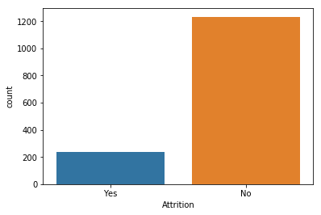

```python
import seaborn as sns
sns.countplot(x="Attrition", data=HR);
```

### Plot Total working years using matplotlib plot function

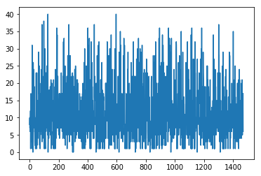

```python
import matplotlib.pyplot as plt
plt.plot(HR['TotalWorkingYears'])
```